# matplotlib.pyplot.figure

**matplotlib.pyplot.figure(*num=None*, *figsize=None*, *dpi=None*, *, *facecolor=None*, *edgecolor=None*, *frameon=True*, *FigureClass=<class 'matplotlib.figure.Figure'>*, *clear=False*, **kwargs)[[source]](https://github.com/matplotlib/matplotlib/blob/v3.10.8/lib/matplotlib/pyplot.py#L871-L1070)**

Create a new figure, or activate an existing figure.

**Parameters:**

**num**int or str or `Figure` or `SubFigure`, optional**

A unique identifier for the figure.

If a figure with that identifier already exists, this figure is made active and returned. An integer refers to the `Figure.number` attribute, a string refers to the figure label.

If there is no figure with the identifier or *num* is not given, a new figure is created, made active and returned. If *num* is an int, it will be used for the `Figure.number` attribute, otherwise, an auto-generated integer value is used (starting at 1 and incremented for each new figure). If *num* is a string, the figure label and the window title is set to this value. If num is a `SubFigure`, its parent `Figure` is activated.

**figsize**(float, float), default: `rcParams["figure.figsize"]` (default: `[6.4, 4.8]`)**

Width, height in inches.

**dpi**float, default: `rcParams["figure.dpi"]` (default: `100.0`)**

The resolution of the figure in dots-per-inch.

**facecolor**[color](https://matplotlib.org/stable/users/explain/colors/colors.html#colors-def), default: `rcParams["figure.facecolor"]` (default: `'white'`)**

The background color.

**edgecolor**[color](https://matplotlib.org/stable/users/explain/colors/colors.html#colors-def), default: `rcParams["figure.edgecolor"]` (default: `'white'`)**

The border color.

**frameon**bool, default: True**

If False, suppress drawing the figure frame.

**FigureClass**subclass of `Figure`**

If set, an instance of this subclass will be created, rather than a plain `Figure`.

**clear**bool, default: False**

If True and the figure already exists, then it is cleared.

**layout**{'constrained', 'compressed', 'tight', 'none', `LayoutEngine`, None}, default: None**

The layout mechanism for positioning of plot elements to avoid overlapping Axes decorations (labels, ticks, etc). Note that layout managers can measurably slow down figure display.

- 'constrained': The constrained layout solver adjusts Axes sizes to avoid overlapping Axes decorations. Can handle complex plot layouts and colorbars, and is thus recommended.

  See [Constrained layout guide](https://matplotlib.org/stable/users/explain/axes/constrainedlayout_guide.html#constrainedlayout-guide) for examples.
- 'compressed': uses the same algorithm as 'constrained', but removes extra space between fixed-aspect-ratio Axes. Best for simple grids of Axes.
- 'tight': Use the tight layout mechanism. This is a relatively simple algorithm that adjusts the subplot parameters so that decorations do not overlap. See `Figure.set_tight_layout` for further details.
- 'none': Do not use a layout engine.
- A `LayoutEngine` instance. Builtin layout classes are `ConstrainedLayoutEngine` and `TightLayoutEngine`, more easily accessible by 'constrained' and 'tight'. Passing an instance allows third parties to provide their own layout engine.

If not given, fall back to using the parameters *tight_layout* and *constrained_layout*, including their config defaults `rcParams["figure.autolayout"]` (default: `False`) and `rcParams["figure.constrained_layout.use"]` (default: `False`).

**kwargs**

Additional keyword arguments are passed to the `Figure` constructor.

**Returns:**

**`Figure`**

#### Notes

A newly created figure is passed to the `new_manager` method or the `new_figure_manager` function provided by the current backend, which install a canvas and a manager on the figure.

Once this is done, `rcParams["figure.hooks"]` (default: `[]`) are called, one at a time, on the figure; these hooks allow arbitrary customization of the figure (e.g., attaching callbacks) or of associated elements (e.g., modifying the toolbar). See [mplcvd -- an example of figure hook](https://matplotlib.org/stable/gallery/user_interfaces/mplcvd.html) for an example of toolbar customization.

If you are creating many figures, make sure you explicitly call `pyplot.close` on the figures you are not using, because this will enable pyplot to properly clean up the memory.

`rcParams` defines the default values, which can be modified in the matplotlibrc file.

## Examples using `matplotlib.pyplot.figure`

[figure not shown]

[The double pendulum problem](https://matplotlib.org/stable/gallery/animation/double_pendulum.html)

The double pendulum problem

[Frame grabbing](https://matplotlib.org/stable/gallery/animation/frame_grabbing_sgskip.html)

Frame grabbing

[figure not shown]

[Rain simulation](https://matplotlib.org/stable/gallery/animation/rain.html)

Rain simulation

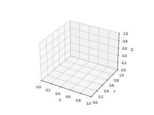

[Animated 3D random walk](https://matplotlib.org/stable/gallery/animation/random_walk.html)

Animated 3D random walk

[figure not shown]

[Matplotlib unchained](https://matplotlib.org/stable/gallery/animation/unchained.html)

Matplotlib unchained

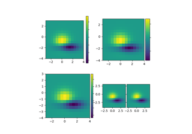

[Axes divider](https://matplotlib.org/stable/gallery/axes_grid1/demo_axes_divider.html)

Axes divider

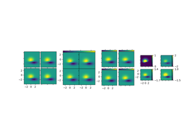

[Demo Axes Grid](https://matplotlib.org/stable/gallery/axes_grid1/demo_axes_grid.html)

Demo Axes Grid

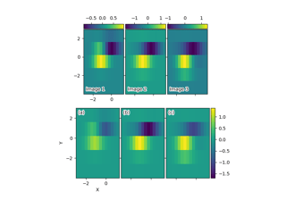

[Axes Grid2](https://matplotlib.org/stable/gallery/axes_grid1/demo_axes_grid2.html)

Axes Grid2

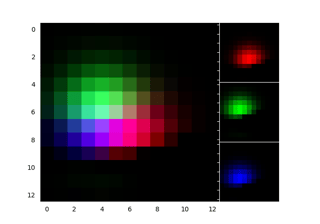

[Show RGB channels using RGBAxes](https://matplotlib.org/stable/gallery/axes_grid1/demo_axes_rgb.html)

Show RGB channels using RGBAxes

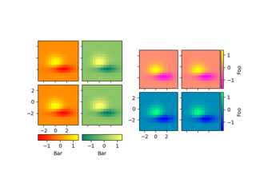

[Per-row or per-column colorbars](https://matplotlib.org/stable/gallery/axes_grid1/demo_edge_colorbar.html)

Per-row or per-column colorbars

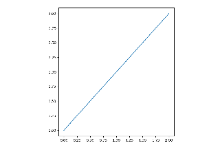

[Axes with a fixed physical size](https://matplotlib.org/stable/gallery/axes_grid1/demo_fixed_size_axes.html)

Axes with a fixed physical size

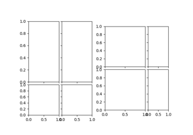

[ImageGrid cells with a fixed aspect ratio](https://matplotlib.org/stable/gallery/axes_grid1/demo_imagegrid_aspect.html)

ImageGrid cells with a fixed aspect ratio

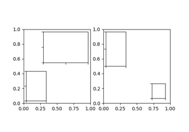

[Inset locator demo](https://matplotlib.org/stable/gallery/axes_grid1/inset_locator_demo.html)

Inset locator demo

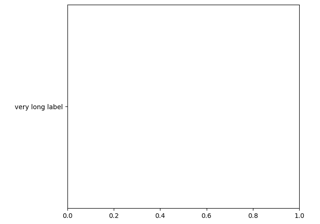

[Make room for ylabel using axes_grid](https://matplotlib.org/stable/gallery/axes_grid1/make_room_for_ylabel_using_axesgrid.html)

Make room for ylabel using axes_grid

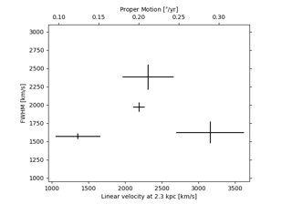

[Parasite Simple2](https://matplotlib.org/stable/gallery/axes_grid1/parasite_simple2.html)

Parasite Simple2

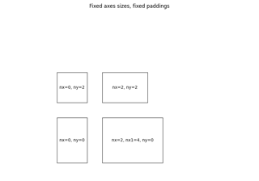

[Simple Axes Divider 1](https://matplotlib.org/stable/gallery/axes_grid1/simple_axes_divider1.html)

Simple Axes Divider 1

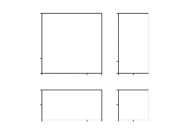

[Simple axes divider 3](https://matplotlib.org/stable/gallery/axes_grid1/simple_axes_divider3.html)

Simple axes divider 3

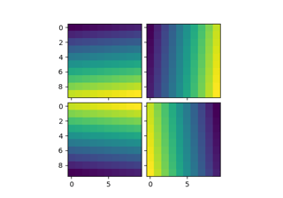

[Simple ImageGrid](https://matplotlib.org/stable/gallery/axes_grid1/simple_axesgrid.html)

Simple ImageGrid

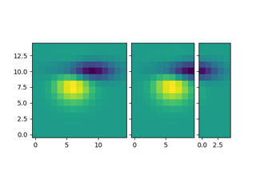

[Simple ImageGrid 2](https://matplotlib.org/stable/gallery/axes_grid1/simple_axesgrid2.html)

Simple ImageGrid 2

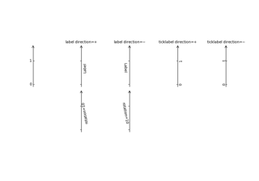

[Axis Direction](https://matplotlib.org/stable/gallery/axisartist/axis_direction.html)

Axis Direction

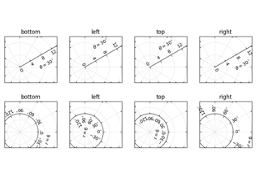

[axis_direction demo](https://matplotlib.org/stable/gallery/axisartist/demo_axis_direction.html)

axis_direction demo

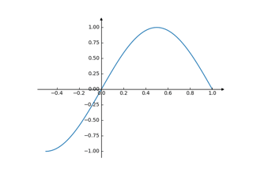

[Axis line styles](https://matplotlib.org/stable/gallery/axisartist/demo_axisline_style.html)

Axis line styles

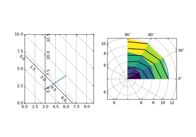

[Curvilinear grid demo](https://matplotlib.org/stable/gallery/axisartist/demo_curvelinear_grid.html)

Curvilinear grid demo

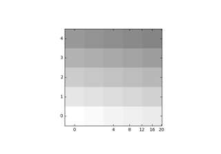

[Demo CurveLinear Grid2](https://matplotlib.org/stable/gallery/axisartist/demo_curvelinear_grid2.html)

Demo CurveLinear Grid2

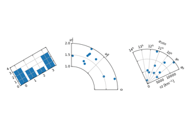

[floating_axes features](https://matplotlib.org/stable/gallery/axisartist/demo_floating_axes.html)

floating_axes features

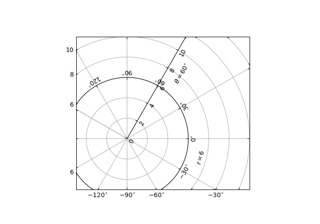

[floating_axis demo](https://matplotlib.org/stable/gallery/axisartist/demo_floating_axis.html)

floating_axis demo

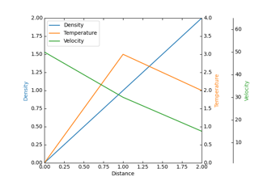

[Parasite Axes demo](https://matplotlib.org/stable/gallery/axisartist/demo_parasite_axes.html)

Parasite Axes demo

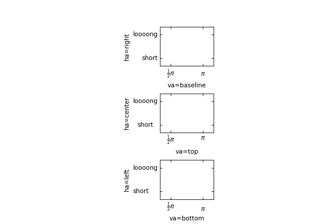

[Ticklabel alignment](https://matplotlib.org/stable/gallery/axisartist/demo_ticklabel_alignment.html)

Ticklabel alignment

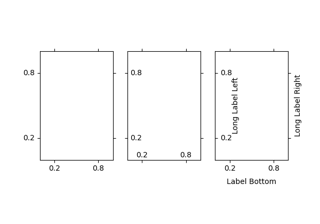

[Ticklabel direction](https://matplotlib.org/stable/gallery/axisartist/demo_ticklabel_direction.html)

Ticklabel direction

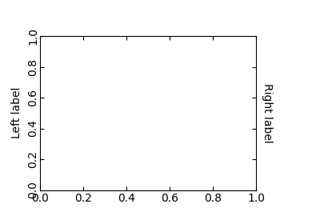

[Simple axis direction](https://matplotlib.org/stable/gallery/axisartist/simple_axis_direction01.html)

Simple axis direction

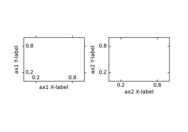

[Simple axis tick label and tick directions](https://matplotlib.org/stable/gallery/axisartist/simple_axis_direction03.html)

Simple axis tick label and tick directions

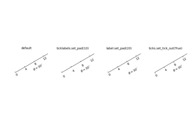

[Simple axis pad](https://matplotlib.org/stable/gallery/axisartist/simple_axis_pad.html)

Simple axis pad

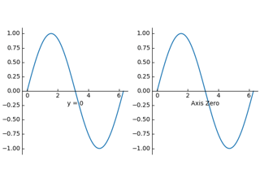

[Custom spines with axisartist](https://matplotlib.org/stable/gallery/axisartist/simple_axisartist1.html)

Custom spines with axisartist

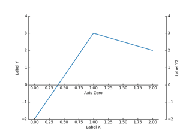

[Simple Axisline](https://matplotlib.org/stable/gallery/axisartist/simple_axisline.html)

Simple Axisline

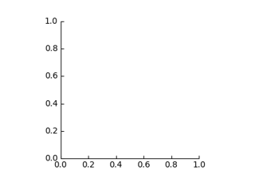

[Simple Axisline3](https://matplotlib.org/stable/gallery/axisartist/simple_axisline3.html)

Simple Axisline3

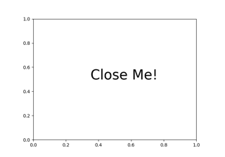

[Close event](https://matplotlib.org/stable/gallery/event_handling/close_event.html)

Close event

[Interactive functions](https://matplotlib.org/stable/gallery/event_handling/ginput_manual_clabel_sgskip.html)

Interactive functions

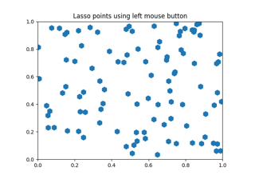

[Lasso Demo](https://matplotlib.org/stable/gallery/event_handling/lasso_demo.html)

Lasso Demo

[figure not shown]

[Barcode](https://matplotlib.org/stable/gallery/images_contours_and_fields/barcode_demo.html)

Barcode

[figure not shown]

[Figimage Demo](https://matplotlib.org/stable/gallery/images_contours_and_fields/figimage_demo.html)

Figimage Demo

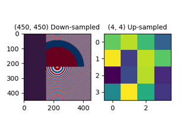

[Image resampling](https://matplotlib.org/stable/gallery/images_contours_and_fields/image_antialiasing.html)

Image resampling

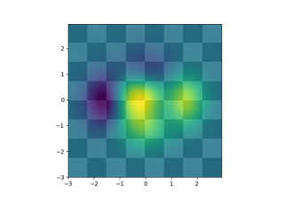

[Layer images with alpha blending](https://matplotlib.org/stable/gallery/images_contours_and_fields/layer_images.html)

Layer images with alpha blending

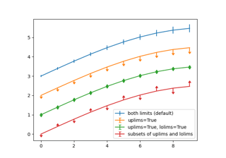

[Errorbar limit selection](https://matplotlib.org/stable/gallery/lines_bars_and_markers/errorbar_limits_simple.html)

Errorbar limit selection

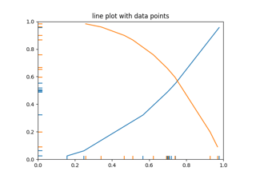

[EventCollection Demo](https://matplotlib.org/stable/gallery/lines_bars_and_markers/eventcollection_demo.html)

EventCollection Demo

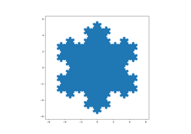

[Filled polygon](https://matplotlib.org/stable/gallery/lines_bars_and_markers/fill.html)

Filled polygon

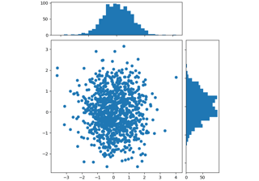

[Scatter plot with histograms](https://matplotlib.org/stable/gallery/lines_bars_and_markers/scatter_hist.html)

Scatter plot with histograms

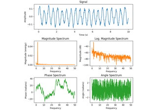

[Spectrum representations](https://matplotlib.org/stable/gallery/lines_bars_and_markers/spectrum_demo.html)

Spectrum representations

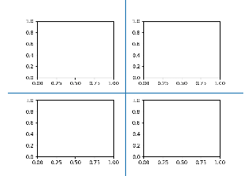

[Add lines directly to a figure](https://matplotlib.org/stable/gallery/misc/fig_x.html)

Add lines directly to a figure

[Hyperlinks](https://matplotlib.org/stable/gallery/misc/hyperlinks_sgskip.html)

Hyperlinks

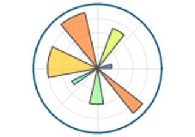

[Matplotlib logo](https://matplotlib.org/stable/gallery/misc/logos2.html)

Matplotlib logo

[Multipage PDF](https://matplotlib.org/stable/gallery/misc/multipage_pdf.html)

Multipage PDF

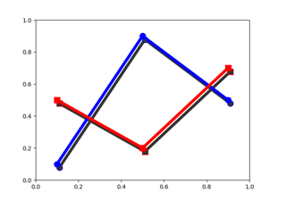

[Apply SVG filter to a line](https://matplotlib.org/stable/gallery/misc/svg_filter_line.html)

Apply SVG filter to a line

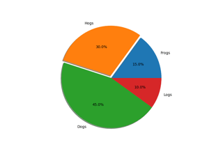

[SVG filter pie](https://matplotlib.org/stable/gallery/misc/svg_filter_pie.html)

SVG filter pie

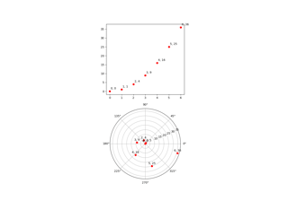

[transforms.offset_copy](https://matplotlib.org/stable/gallery/misc/transoffset.html)